# Deep Learning- 課程 09－Deep Learning- An Introduction To Deep Learning Network - Keras Build A Deep Network Part- 01- Python Tutorial

''' 人工智慧- 進階課程 A.I Tutorials - Advanced Course - Deep Learning 教程 ''' 05 - 深度學習 教程 課程 09 - Deep Learning - An Introduction To Deep Learning Network Part- 01 - Keras Build A Deep Learning Network 程式範例 - Keras 創建 - Keras Build A Deep Learning Network Model - Keras 建立 深度學習網絡 模型 ''' ''' >> 資料準備 >> 你我互動學習園地- 進階課程 Advanced Course >> https://interactiveuandmetutorialsac.weebly.com/ >> 你我互動學習園地 >> https://interactiveuandmetutorials.weebly.com/ >> Python 程式語言 設計 >> https://pythonprogrammingtutorials.weebly.com/ >> 目錄結構 : >> Deep Learning- 09 - Deep Learning - An Introduction To Deep Learning Network Part- 01.zip 檔案路徑/ ├── 09 - Deep Learning - An Introduction To Deep Learning Network Part- 01.ipynb '''

''' - Keras 函庫式 - API - 使用 Keras - 創建 深度學習 模型 Keras 文獻參考: * [Keras官網 keras.io](http://keras.io/) * [Keras官網 keras.io](https://keras.io/applications/) '''''' - Keras - 創建深度學習模型 - 簡單/快速 - 序列式(Sequential) - API - 允許逐層堆疊創建模型 - 很多深度學習網絡結構的構建 - 但是它也有限制 - 不允許創建模型 - 有共享層 - 有多個輸入 - 或輸出的網絡 - 函數式(Functional) - API - 是創建網絡模型的另一種方式 - 提供了更多的靈活性 - 包括創建更複雜的模型 - Keras中 - 函數式(Functional) - API - 定義深度學習模型 - Sequential和Functional - API之間 的區別 - 函數式(Functional) - API - 定義 - 多層感知器 (MLP) 模型 - 卷積神經網絡(CNN) 模型 - 遞歸神經網絡(RNN) 模型 - 複雜的模型 - 如何用共享層和多個輸入輸出 '''

[figure not shown]

# Import 相關函式庫

```python
import platform
```

```python
!python -V
platform.python_version()
```

```
Python 3.7.3
```

```
'3.7.3'
```

```python
import platform
import tensorflow
import keras
print("Platform: {}".format(platform.platform()))
print("Tensorflow version: {}".format(tensorflow.__version__))
print("Keras version: {}".format(keras.__version__))
```

```
Platform: Windows-10-10.0.18362-SP0
Tensorflow version: 1.14.0
Keras version: 2.2.4
```

```python
%matplotlib inline
import matplotlib.pyplot as plt
import matplotlib.image as mpimg
import numpy as np
from IPython.display import Image
```

- Install plot_model/ Image
  - pip install graphviz
  - pip install pydot

```python
import pydot
from IPython.display import Image
from keras.utils import plot_model
```

''' - Keras 序列式 模型 - Sequential Models - 序列式(Sequential) - API - 允許 逐層堆疊 創建模型 - 很多深度學習網絡結構的構建 - 但是它也有限制 - 不允許 創建模型 - 有共享層 - 有多個輸入 - 或輸出的網絡 - 創建深度學習模型 - 透過 Kears - Sequential類別 - 創建模型 圖層 - 並 添加到其中 - 可以 定義 多個圖層 - 以 陣列的方式 - 一次 - 做為參數傳 遞給 Sequential '''

```python
# 構建模型

from keras.models import Sequential
from keras.layers import Dense

model = Sequential([Dense(2, input_shape=(1,)), Dense(1)])
```

```python
model.summary()
```

[output not shown]

## 一層一層 分段 添加上去

```python
# 構建模型

from keras.models import Sequential
from keras.layers import Dense

model = Sequential()
model.add(Dense(2, input_shape=(1,)))
model.add(Dense(1))
```

```python
model.summary()
```

```
_________________________________________________________________
Layer (type)                 Output Shape              Param #
=================================================================
dense_3 (Dense)              (None, 2)                 4
_________________________________________________________________
dense_4 (Dense)              (None, 1)                 3
=================================================================
Total params: 7
Trainable params: 7
Non-trainable params: 0
_________________________________________________________________
```

''' - 序列式(Sequential) 模型 - API - 大多數情況下非常有用與方便 - 有一些局限性 Limitation - 例如 - 網絡拓撲結構可能具有多個不同輸入 - 產生多個輸出 - 或 重複使用共享圖層的複雜模型 ''' ''' - 函數式(Functional) - API 構建模型 - 是創建網絡模型的 另一種方式 - 提供了 更多的靈活性 - 包括 創建 更複雜的 模型 '''

''' - Keras 函數式 (Functional) - API 構建模型 - 提供了更為靈活的方式。 - 允許 - 定義多個輸入 或 輸出模型以及 共享圖層的模型 - 定義動態(ad-hoc)的非週期性(acyclic)網絡 - 模型 - 通過創建層 - (Layer instances) - 將它們直接相互連接成對 - 然後定義一個模型(model) - 來指定那些層 是要作為 - 模型的 - 輸入和輸出 ''' ''' - 函數式 (Functional) - API 構建模型 - 三個獨特特性 - 1.0 定義輸入 '''''' - 與 Sequential模型不同 - 必須創建獨立的 Input層物件 - 並定義輸入數據張量的 維度形狀 (Tensor Shape) - 輸入層 採用一個張量形狀參數 (tensor shape) - 是一個 Tuple - 宣吿 輸入張量的維度 - 例如: - MNIST的每張圖像(28x28) - 打平成一個一維(784)的張量 - 做為一個 多層感知器(MLP) - Input '''

```python
from keras.layers import Input

mnist_input = Input(shape=(784,))
```

```python
mnist_input.shape,mnist_input.dtype
```

```
(TensorShape([Dimension(None), Dimension(784)]), tf.float32)
```

''' - 函數式(Functional) - API 構建模型 - 三個獨特特性 - 2.0 連接不同的網絡層 '''''' - 模型中的神經層是成對連接的 - 像是一個樂高積木一樣有一面是凸一面是凹 - 一個神經層的輸出會接到另一個神經層的輸入 - 定義每個新神經層時指定輸入的來源來完成的 - 使用括號表示法 - 以便在創建圖層之後 - 指定作為 輸入的神經層 - 例子 - 可以像上面那樣創建輸入層 - 然後創建一個隱藏層作為密集層 - 接收來自輸入層的輸入 ''''

```python
from keras.layers import Input
from keras.layers import Dense

mnist_input = Input(shape=(784,))
hidden = Dense(512)(mnist_input)
```

```python
hidden.shape,hidden.dtype
```

```
(TensorShape([Dimension(None), Dimension(512)]), tf.float32)
```

''' - 函數式(Functional) - API 構建模型 - 逐層連接的方式 - 賦予功能性(Functional) API靈活性 '''

''' - 函數式(Functional) - API 構建模型 - 三個獨特特性 - 3.0 創建模型 '''''' - 創建所有模型圖層 並將它們連接在一起之後 - 必須定義一個模型(Model)物件 - 與 Sequential API一樣 - 模型 - 用於總結(Summarize)，擬合(Fit)，評估(Evaluate) 和 預測(Predict) - Keras - 提供了一個 Model 類別 - 可以從創建的圖層創建模型的instance - 指定整個模型的第一個輸入層 和 最後一個的輸出層 '''

```python
# 構建模型


from keras.layers import Input
from keras.layers import Dense
from keras.models import Model

mnist_input = Input(shape=(784,))
hidden = Dense(512)(mnist_input)

model = Model(inputs=mnist_input, outputs=hidden)
```

```python
model.summary()
```

```
_________________________________________________________________
Layer (type)                 Output Shape              Param #
=================================================================
input_3 (InputLayer)         (None, 784)               0
_________________________________________________________________
dense_6 (Dense)              (None, 512)               401920
=================================================================
Total params: 401,920
Trainable params: 401,920
Non-trainable params: 0
_________________________________________________________________
```

''' - Keras函數式 API的 所有關鍵部分 - 通過定義 一系列 - 不同的模型 - 來開展 - model.summary() '''

''' - 標準 網絡模型 '''''' - 函數式(Functional) - API 構建模型 - 使用 函數式 API 時 - 先看一些標準的神經網絡模型是如何定義的 - 定義 - 多層感知器 (MLP) - 卷積神經網絡(CNN) - 遞歸神經網絡(RNN) '''

''' - 多層感知器(Multilayer Perceptron) - 定義了一個多類別分類 (multi-class classification) 的 多層感知器(MLP)模型 - 模型 784個輸入，3個隱藏層，512,216 和 128個 隱藏神經元 - 輸出層有 10個 輸出 - 每個隱藏層中使用 - relu - 激活函數 - 輸出層中使用 - softmax - 激活函數 - 進行 多類別 分類 ''''

- Install plot_model/ Image
  - pip install graphviz
  - pip install pydot

```python
import pydot
from keras.utils import plot_model
```

```
_________________________________________________________________
Layer (type)                 Output Shape              Param #
=================================================================
input (InputLayer)           (None, 784)               0
_________________________________________________________________
hidden1 (Dense)              (None, 512)               401920
_________________________________________________________________
hidden2 (Dense)              (None, 216)               110808
_________________________________________________________________
hidden3 (Dense)              (None, 128)               27776
_________________________________________________________________
output (Dense)               (None, 10)                1290
=================================================================
Total params: 541,794
Trainable params: 541,794
Non-trainable params: 0
_________________________________________________________________
```

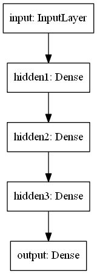

```python
# 多層感知器(MLP)模型


from keras.models import Model
from keras.layers import Input, Dense
from keras.utils  import plot_model

mnist_input = Input(shape=(784,), name='input')
hidden1 = Dense(512, activation='relu', name='hidden1')(mnist_input)
hidden2 = Dense(216, activation='relu', name='hidden2')(hidden1)
hidden3 = Dense(128, activation='relu', name='hidden3')(hidden2)
output = Dense(10, activation='softmax', name='output')(hidden3)

model = Model(inputs=mnist_input, outputs=output)

# 打印網絡結構
model.summary()

# 產生網絡拓撲圖
plot_model(model, to_file='multilayer_perceptron_graph.png')

# 顯示網絡拓撲圖
Image('multilayer_perceptron_graph.png')
```

''' - 卷積神經網絡 (CNN) - 定義一個用於圖像分類的卷積神經網絡(convolutional neural network) - 模型 - 灰階的 28×28 圖像 - 輸入 - 1 個作為 特徵提取器的兩個卷積 和池化層 的 序列 - 一個完全連接層 FC 來 解釋特徵 - 輸出層 - 10類 預測的 Softmax 激活函數 - 進行 多類別 分類 ''''

```
_________________________________________________________________
Layer (type)                 Output Shape              Param #
=================================================================
input (InputLayer)           (None, 28, 28, 1)         0
_________________________________________________________________
conv1 (Conv2D)               (None, 25, 25, 128)       2176
_________________________________________________________________
pool1 (MaxPooling2D)         (None, 12, 12, 128)       0
_________________________________________________________________
conv2 (Conv2D)               (None, 9, 9, 64)          131136
_________________________________________________________________
pool2 (MaxPooling2D)         (None, 4, 4, 64)          0
_________________________________________________________________
hidden1 (Dense)              (None, 4, 4, 64)          4160
_________________________________________________________________
output (Dense)               (None, 4, 4, 10)          650
=================================================================
Total params: 138,122
Trainable params: 138,122
Non-trainable params: 0
_________________________________________________________________
```

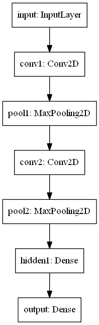

```python
# 卷積神經網絡 (CNN)

from keras.models import Model
from keras.layers import Input, Dense
from keras.layers.convolutional import Conv2D
from keras.layers.pooling import MaxPool2D
from keras.utils import plot_model

mnist_input = Input(shape=(28, 28, 1), name='input')

conv1 = Conv2D(128, kernel_size=4, activation='relu', name='conv1')(mnist_input)
pool1 = MaxPool2D(pool_size=(2, 2), name='pool1')(conv1)

conv2 = Conv2D(64, kernel_size=4, activation='relu', name='conv2')(pool1)
pool2 = MaxPool2D(pool_size=(2, 2), name='pool2')(conv2)

hidden1 = Dense(64, activation='relu', name='hidden1')(pool2)
output = Dense(10, activation='softmax', name='output')(hidden1)
model = Model(inputs=mnist_input, outputs=output)

# 顯示 網絡結構
model.summary()

# 產生網絡拓撲圖
plot_model(model, to_file='convolutional_neural_network.png')

# 顯示 網絡拓撲圖
Image('convolutional_neural_network.png')
```

''' - 遞歸神經網絡 (RNN) - 定義一個 長期短期記憶 (LSTM)遞歸神經網絡 - 用於 圖像分類 - 模型 - 一個特徵的 784個時間步驟 - 輸入 - 完全連接的層來解釋LSTM 輸出 - 輸出層 - 10類 預測的 Softmax 激活函數 - 進行 多類別 分類 ''''

```
_________________________________________________________________
Layer (type)                 Output Shape              Param #
=================================================================
input (InputLayer)           (None, 784, 1)            0
_________________________________________________________________
lstm1 (LSTM)                 (None, 128)               66560
_________________________________________________________________
hidden1 (Dense)              (None, 128)               16512
_________________________________________________________________
output (Dense)               (None, 10)                1290
=================================================================
Total params: 84,362
Trainable params: 84,362
Non-trainable params: 0
_________________________________________________________________
```

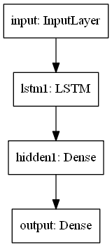

```python
# 遞歸神經網絡 (RNN)

from keras.models import Model
from keras.layers import Input, Dense
from keras.layers.recurrent import LSTM
from keras.utils import plot_model


# 每一個像素 - 想成是一序列有前後關係的 time_steps

mnist_input = Input(shape=(784, 1), name='input')
lstm1 = LSTM(128, name='lstm1')(mnist_input)
hidden1 = Dense(128, activation='relu', name='hidden1')(lstm1)
output = Dense(10, activation='softmax', name='output')(hidden1)
model = Model(inputs=mnist_input, outputs=output)

# 顯示 網絡結構
model.summary()

# 產生 網絡拓撲圖
plot_model(model, to_file='recurrent_neural_network.png')

# 顯示 網絡拓撲圖
Image('recurrent_neural_network.png')
```

''' - 共享層模型 - 多個神經層 可以共享 一個神經層的輸出 - 當成輸入 - 1 個輸入可能 可以有多個 不同的 特徵提取層 - 或者多個神經層用於 解釋 特徵提取層的輸出 - 共享輸入層 (Shared Input Layer) - 模型 - 28×28像素 的 灰階圖像 - 兩個CNN 特徵提取 子模型 共享這個輸入 - 第一個具有 4的內核大小 - 第二個具有 8的內核大小 - 特徵提取子模型的輸出 - 平坦化(Flatten) - 為向量(Vector) - 被串連成一個 長向量 - 輸出層 - 10類 預測的 Softmax 激活函數 - 進行 多類別 分類 ''''

```
__________________________________________________________________________________________________
Layer (type)                    Output Shape         Param #     Connected to
==================================================================================================
input (InputLayer)              (None, 28, 28, 1)    0
__________________________________________________________________________________________________
conv1 (Conv2D)                  (None, 25, 25, 32)   544         input[0][0]
__________________________________________________________________________________________________
conv2 (Conv2D)                  (None, 21, 21, 16)   1040        input[0][0]
__________________________________________________________________________________________________
pool1 (MaxPooling2D)            (None, 12, 12, 32)   0           conv1[0][0]
__________________________________________________________________________________________________
pool2 (MaxPooling2D)            (None, 10, 10, 16)   0           conv2[0][0]
__________________________________________________________________________________________________
flatten_1 (Flatten)             (None, 4608)         0           pool1[0][0]
__________________________________________________________________________________________________
flatten_2 (Flatten)             (None, 1600)         0           pool2[0][0]
__________________________________________________________________________________________________
concatenate_1 (Concatenate)     (None, 6208)         0           flatten_1[0][0]
                                                                 flatten_2[0][0]
__________________________________________________________________________________________________
hidden1 (Dense)                 (None, 64)           397376      concatenate_1[0][0]
__________________________________________________________________________________________________
output (Dense)                  (None, 10)           650         hidden1[0][0]
==================================================================================================
Total params: 399,610
Trainable params: 399,610
Non-trainable params: 0
__________________________________________________________________________________________________
```

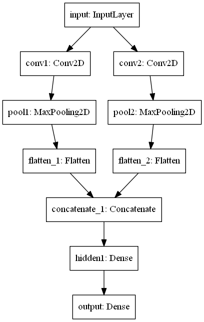

```python
# 共享輸入層

from keras.models import Model
from keras.layers import Input, Dense, Flatten
from keras.layers.convolutional import Conv2D
from keras.layers.pooling import MaxPool2D
from keras.layers.merge import concatenate
from keras.utils import plot_model

# 輸入層
mnist_input = Input(shape=(28, 28, 1), name='input')

# 第一個特徵提取層
conv1 = Conv2D(32, kernel_size=4, activation='relu', name='conv1')(mnist_input) #
pool1 = MaxPool2D(pool_size=(2, 2), name='pool1')(conv1)
flat1 = Flatten()(pool1)

# 第二個特徵提取層
conv2 = Conv2D(16, kernel_size=8, activation='relu', name='conv2')(mnist_input) #
pool2 = MaxPool2D(pool_size=(2, 2), name='pool2')(conv2)
flat2 = Flatten()(pool2)

# 把兩個特徵提取層的結果 - 併起來
merge = concatenate([flat1, flat2])

# 進行 - 全連結層
hidden1 = Dense(64, activation='relu', name='hidden1')(merge)

# 輸出層 Output Layer
output = Dense(10, activation='softmax', name='output')(hidden1)

# Model - 組合整個網絡
model = Model(inputs=mnist_input, outputs=output)

# 顯示 網絡結構
model.summary()

# plot graph
plot_model(model, to_file='shared_input_layer.png')

# 顯示 網絡拓撲圖
Image('shared_input_layer.png')
```

```
__________________________________________________________________________________________________
Layer (type)                    Output Shape         Param #     Connected to
==================================================================================================
input (InputLayer)              (None, 784, 1)       0
__________________________________________________________________________________________________
lstm1 (LSTM)                    (None, 128)          66560       input[0][0]
__________________________________________________________________________________________________
interp21 (Dense)                (None, 64)           8256        lstm1[0][0]
__________________________________________________________________________________________________
interp22 (Dense)                (None, 32)           2080        interp21[0][0]
__________________________________________________________________________________________________
interp1 (Dense)                 (None, 10)           1290        lstm1[0][0]
__________________________________________________________________________________________________
interp23 (Dense)                (None, 16)           528         interp22[0][0]
__________________________________________________________________________________________________
merge (Concatenate)             (None, 26)           0           interp1[0][0]
                                                                 interp23[0][0]
__________________________________________________________________________________________________
output (Dense)                  (None, 10)           270         merge[0][0]
==================================================================================================
Total params: 78,984
Trainable params: 78,984
Non-trainable params: 0
__________________________________________________________________________________________________
```

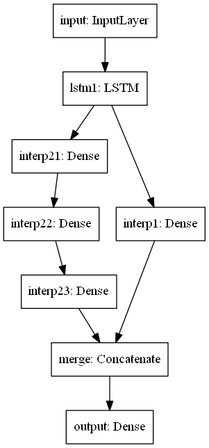

```python
# 共享特徵提取層 (Shared Feature Extraction Layer)

from keras.models import Model
from keras.layers import Input, Dense
from keras.layers.recurrent import LSTM
from keras.layers.merge import concatenate
from keras.utils import plot_model

# 輸入層
# 把每一個像素想成是一序列有前後關係的time_steps
mnist_input = Input(shape=(784, 1), name='input')

# 特徵提取層
extract1 = LSTM(128, name='lstm1')(mnist_input)

# 第一個解釋層
interp1 = Dense(10, activation='relu', name='interp1')(extract1)

# 第二個解釋層
interp21 = Dense(64, activation='relu', name='interp21')(extract1)
interp22 = Dense(32, activation='relu', name='interp22')(interp21)
interp23 = Dense(16, activation='relu', name='interp23')(interp22)

# 把兩個特徵提取層的結果 - 併起來
merge = concatenate([interp1, interp23], name='merge')

# 輸出層
output = Dense(10, activation='softmax', name='output')(merge)

# Model組合 整個網絡
model = Model(inputs=mnist_input, outputs=output)

# 顯示 網絡結構
model.summary()

# plot graph
plot_model(model, to_file='shared_feature_extractor.png')

# 顯示 網絡拓撲圖
Image('shared_feature_extractor.png')
```

''' - 多種輸入 和 輸出模型 - 函數式(functional) - API - 也可用於開發具有多個輸入或多個輸出的模型 - 更複雜的模型 - 圖像分類模型 - 圖像的兩個版本作為輸入，每個圖像的大小不同 - 一個灰階的 64×64 - 一個彩色的 32×32 - 特徵提取 CNN模型 - 對每個模型 -進行操作 - 然後將兩個模型的結果連接起 來進行 解釋和 最終預測 - 輸出層 - 10類 預測的 Softmax 激活函數 - 進行 多類別 分類 - 創建 Model() - 兩個輸入圖層定義為一個數組(Array) '''

```
__________________________________________________________________________________________________
Layer (type)                    Output Shape         Param #     Connected to
==================================================================================================
img_gray_bigsize (InputLayer)   (None, 64, 64, 1)    0
__________________________________________________________________________________________________
img_rgb_smallsize (InputLayer)  (None, 32, 32, 3)    0
__________________________________________________________________________________________________
conv11 (Conv2D)                 (None, 61, 61, 32)   544         img_gray_bigsize[0][0]
__________________________________________________________________________________________________
conv21 (Conv2D)                 (None, 29, 29, 32)   1568        img_rgb_smallsize[0][0]
__________________________________________________________________________________________________
pool11 (MaxPooling2D)           (None, 30, 30, 32)   0           conv11[0][0]
__________________________________________________________________________________________________
pool21 (MaxPooling2D)           (None, 14, 14, 32)   0           conv21[0][0]
__________________________________________________________________________________________________
conv12 (Conv2D)                 (None, 27, 27, 16)   8208        pool11[0][0]
__________________________________________________________________________________________________
conv22 (Conv2D)                 (None, 11, 11, 16)   8208        pool21[0][0]
__________________________________________________________________________________________________
pool12 (MaxPooling2D)           (None, 13, 13, 16)   0           conv12[0][0]
__________________________________________________________________________________________________
pool22 (MaxPooling2D)           (None, 5, 5, 16)     0           conv22[0][0]
__________________________________________________________________________________________________
flatten_3 (Flatten)             (None, 2704)         0           pool12[0][0]
__________________________________________________________________________________________________
flatten_4 (Flatten)             (None, 400)          0           pool22[0][0]
__________________________________________________________________________________________________
concatenate_2 (Concatenate)     (None, 3104)         0           flatten_3[0][0]
                                                                 flatten_4[0][0]
__________________________________________________________________________________________________
hidden1 (Dense)                 (None, 128)          397440      concatenate_2[0][0]
__________________________________________________________________________________________________
hidden2 (Dense)                 (None, 64)           8256        hidden1[0][0]
__________________________________________________________________________________________________
output (Dense)                  (None, 10)           650         hidden2[0][0]
==================================================================================================
Total params: 424,874
Trainable params: 424,874
Non-trainable params: 0
__________________________________________________________________________________________________
```

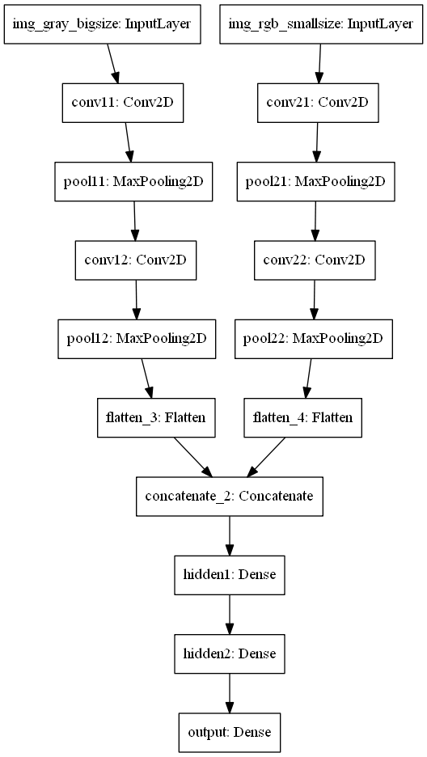

```python
# 多輸入模型

from keras.models import Model
from keras.layers import Input, Dense, Flatten
from keras.layers.convolutional import Conv2D
from keras.layers.pooling import MaxPool2D
from keras.layers.merge import concatenate
from keras.utils import plot_model

# 第一個輸入層
img_gray_bigsize = Input(shape=(64, 64, 1), name='img_gray_bigsize')
conv11 = Conv2D(32, kernel_size=4, activation='relu', name='conv11')(img_gray_bigsize)
pool11 = MaxPool2D(pool_size=(2, 2), name='pool11')(conv11)
conv12 = Conv2D(16, kernel_size=4, activation='relu', name='conv12')(pool11)
pool12 = MaxPool2D(pool_size=(2, 2), name='pool12')(conv12)
flat1 = Flatten()(pool12)

# 第二個輸入層
img_rgb_smallsize = Input(shape=(32, 32, 3), name='img_rgb_smallsize')
conv21 = Conv2D(32, kernel_size=4, activation='relu', name='conv21')(img_rgb_smallsize)
pool21 = MaxPool2D(pool_size=(2, 2), name='pool21')(conv21)
conv22 = Conv2D(16, kernel_size=4, activation='relu', name='conv22')(pool21)
pool22 = MaxPool2D(pool_size=(2, 2), name='pool22')(conv22)
flat2 = Flatten()(pool22)

# 把兩個特徵提取層的結果 - 併起來
merge = concatenate([flat1, flat2])

# 用隱藏的全連結層來 - 解釋特徵
hidden1 = Dense(128, activation='relu', name='hidden1')(merge)
hidden2 = Dense(64, activation='relu', name='hidden2')(hidden1)

# 輸出層
output = Dense(10, activation='softmax', name='output')(hidden2)

# Model 組合整個網絡
model = Model(inputs=[img_gray_bigsize, img_rgb_smallsize], outputs=output)

# 顯示  網絡結構
model.summary()

# plot graph
plot_model(model, to_file='multiple_inputs.png')

# 顯示  網絡拓撲圖
Image('multiple_inputs.png')
```

```
__________________________________________________________________________________________________
Layer (type)                    Output Shape         Param #     Connected to
==================================================================================================
input (InputLayer)              (None, 784, 1)       0
__________________________________________________________________________________________________
extract (LSTM)                  (None, 784, 64)      16896       input[0][0]
__________________________________________________________________________________________________
class11 (LSTM)                  (None, 32)           12416       extract[0][0]
__________________________________________________________________________________________________
class12 (Dense)                 (None, 32)           1056        class11[0][0]
__________________________________________________________________________________________________
output1 (Dense)                 (None, 10)           330         class12[0][0]
__________________________________________________________________________________________________
output2 (TimeDistributed)       (None, 784, 10)      650         extract[0][0]
==================================================================================================
Total params: 31,348
Trainable params: 31,348
Non-trainable params: 0
__________________________________________________________________________________________________
(?, 784, 1)
```

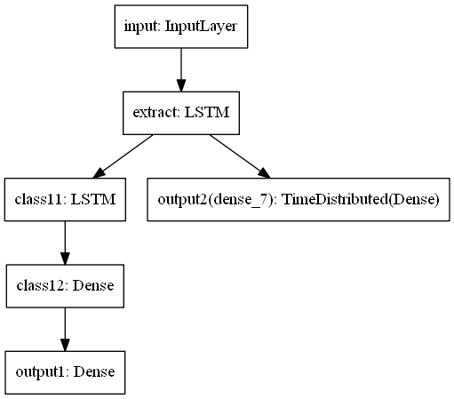

```python
# 多輸出模型

from keras.models import Model
from keras.layers import Input, Dense
from keras.layers.recurrent import LSTM
from keras.layers.wrappers import TimeDistributed
from keras.utils import plot_model

# 輸入層
# 把每一個像素 - 想成是一序列有前後關係的 time_steps
mnist_input = Input(shape=(784, 1), name='input')

# 特徵擷取層
extract = LSTM(64, return_sequences=True, name='extract')(mnist_input)

# 分類輸出
class11 = LSTM(32, name='class11')(extract)
class12 = Dense(32, activation='relu', name='class12')(class11)
output1 = Dense(10, activation='softmax', name='output1')(class12)

# 序列 輸出
output2 = TimeDistributed(Dense(10, activation='softmax'), name='output2')(extract)

# Model來組合 整個網絡
model = Model(inputs=mnist_input, outputs=[output1, output2])

# 顯示 網絡結構
model.summary()
print(mnist_input.shape)

# plot graph
plot_model(model, to_file='multiple_outputs.png')

# 顯示 網絡拓撲圖
Image('multiple_outputs.png')
```